# R Project

# Part 1 - Simulate random points on earth

These are helper functions that convert coordinates between spherical and cartesian:

```r
# Convert to Cartesian coordinates: the function assumes that theta is in [0,pi] and phi is in [0,2pi]

spherical_to_cartesian <- function(point)

{

  x <- point$r*cos(point$phi)*sin(point$theta)

  y <- point$r*sin(point$phi)*sin(point$theta)

  z <- point$r*cos(point$theta)



  return(list(x=x,y=y,z=z))

}



# Convert to Spherical coordinates: the function assumes that theta is in [0,pi] and phi is in [0,2pi]

cartesian_to_spherical <- function(point)

{

  r <- sqrt(point$x**2+point$y**2+point$z**2)

  phi <- atan(point$y/point$x) + pi * ( 1 - sign(point$y)*(1+sign(point$x))/2 )  # take care of all sign cases. When x=0 or y=0 exactly, the function may not work correctly, but these are events of measure zero for any continuous distribution over the sphere.

  theta <- acos(point$z/r)

  return(list(r=r,phi=phi,theta=theta))

}



# Geodesic distance between points.

# Input format: p1 and p2 are lists having items: r, phi, theta in spherical coordinates,

# i.e. phi in [0,2pi] and theta in [0,pi]

geodesic_dist <- function(p1, p2)

{

  return ( p1$r * acos( cos(p1$theta)*cos(p2$theta) + sin(p1$theta)*sin(p2$theta) * cos(p1$phi-p2$phi) ) )

}
```

### Calculating the average **Geodesic Distance** on the face of the earth:

First, I will sample 1000 pairs of points, and calculate the distance between them, using *replicate*. In order to keep the code tidy, I created a helper function called *sample_point* that samples a point using *runif_on_sphere* function, and then renames the items as x,y,z in order to fit the helper function demands, which calculates the geodesic distance.

```r
sample_point <- function(){ # This function samples from earth and then names the coordinates of the Cartesian sample into "x", "y", "z", so it will fit the helper function demands.
  s_point <- list(runif_on_sphere(n=1,d=3,r=6371))
  return(list(x = s_point[[1]][1], y = s_point[[1]][2], z = s_point[[1]][3]))
}

B <- 1000 # set the number of repetitions

geodesic_distances <- replicate(B,geodesic_dist(cartesian_to_spherical(point=sample_point()),cartesian_to_spherical(point=sample_point()))) # create a sample sized 1000 of geodesic distances
```

The average Geodesic Distance is

```r
mean(geodesic_distances)
```

```
## [1] 10228.35
```

It’s nice to see that the mean geodesic distance is approximately equal to a quarter of an entire circulation or the planet:

```r
2*pi*6371/4
```

```
## [1] 10007.54
```

### Calculating the average **Euclidean Distance**:

```r
euclidean_dist <- function(p1,p2){
  return(((p1$x-p2$x)^2+(p1$y-p2$y)^2+(p1$z-p2$z)^2)^0.5)
}


B <- 1000

euclidean_distances <- replicate(B,euclidean_dist(sample_point(),sample_point()))
```

The average Euclidean Distance is

```r
mean(euclidean_distances)
```

```
## [1] 8499.825
```

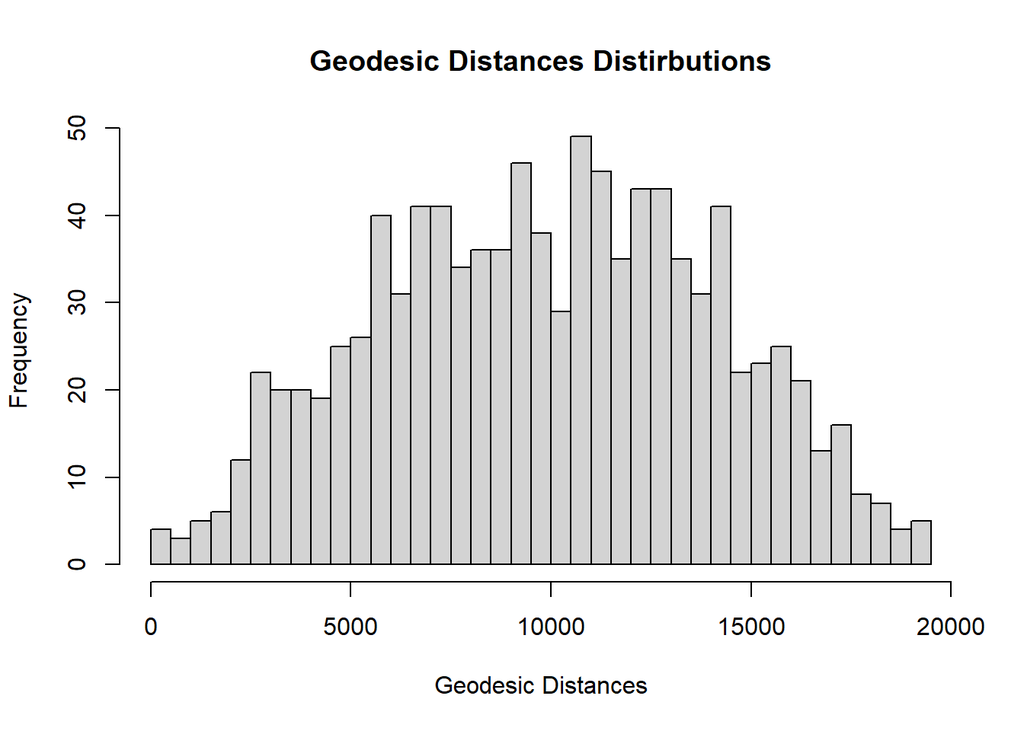

```r
B <- 1000

geodesic_distances <- replicate(B,geodesic_dist(cartesian_to_spherical(point=sample_point()),cartesian_to_spherical(point=sample_point())))

hist(geodesic_distances,xlab = "Geodesic Distances",main = "Geodesic Distances Distirbutions", breaks = 30)
```

```r
skewness(geodesic_distances)
```

```
## [1] -0.02152107
```

```r
kurtosis(geodesic_distances)
```

```
## [1] -0.7510851
```

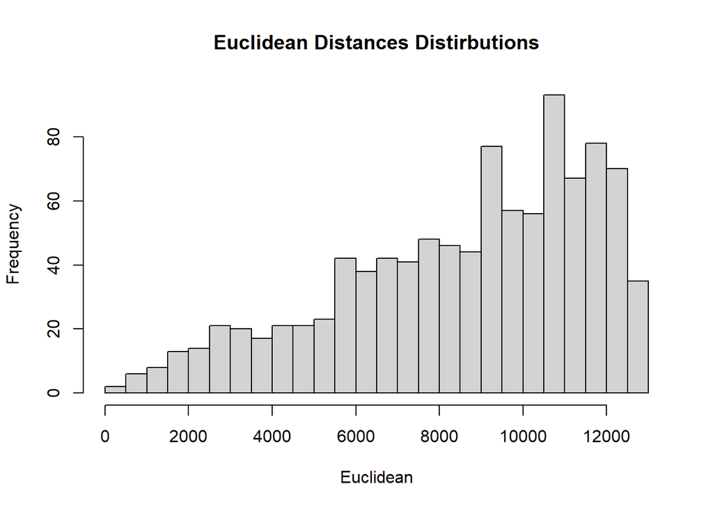

```r
euclidean_distances <- replicate(B,euclidean_dist(sample_point(),sample_point())) # create a sample sized 1000 of geodesic distances

hist(euclidean_distances,xlab = "Euclidean",main = "Euclidean Distances Distirbutions", breaks = 30)
```

```r
skewness(euclidean_distances)
```

```
## [1] -0.6825428
```

```r
kurtosis(euclidean_distances)
```

```
## [1] -0.4188684
```

The Geodesic Distance distribution Is more similar to the normal distribution - Its empirical distribution’s plot shows that the majority of the samples are centered along some expected value, with tails on both sides, in similar with the normal distribution. In contrast, the Euclidian Distance distribution has a more significant left tail.

### generating random points from a specific country using rejection sampling:

First I’ll create a helper function that converts from spherical to geographical coordinates. I use this function in order to convert the coordinates to ones I can find them on the map.

```r
spherical_to_geographical <- function(point){
  lat <- point$theta*180/pi-90
  long <- point$phi*180/pi-180
  return(list(long=long, lat = lat))
}
```

Next is a function that receives the number of samples, and the country’s name, and returns an array of points in that country. This function works in a way of rejection sampling. It samples a point. If it is in the desired country, then the point is returned. Otherwise, while the point is not in the country, it keeps sampling again and again.

This was my original function, which worked, but took very long time to sample 1000 points from the USA with. So finally, I used another function which will be explained further down. I leave this function for possible future use in the document.

```r
sample_from_country<- function(n,country){ # sample n points from the country
  random_points <- replicate(n,sample_point_from_country(country))
  return(random_points)
}

sample_point_from_country <- function(country){
  point <- cartesian_to_spherical(sample_point()) # sample a first point and turn it to geographic

  while (strsplit(map.where("world", spherical_to_geographical(point)), "[:]")[[1]][1] != country | is.na(map.where("world", spherical_to_geographical(point)))){ # while the point is not in the designated country, keep sampling
    point <- cartesian_to_spherical(sample_point())
  }
  return(point) # return the point once it is in the country, in spheric coordinates
}
```

Due to the long running time of my previous functions, I created an additional function, that does exactly the same, but instead of sampling 1 sample each time, it samples 2000, and this way the chances of getting the country are higher.

While the number of samples from the desired country is smaller than n, it keeps sampling in the same way another 1000, each time r-binding all the previous samples with the new samples, until n samples from the country are achieved.

I chose these numbers after testing the running times of several numbers, and found that for sampling 1 point from a country, they work quite fast.

**cartesians_to_geos** - This function converts multiple catresian points into their geographic pattern **sample_n_from_country** - receives a number n and a country, and returns n samples of that country.

```r
cartesians_to_geos <- function(points){ # points is a DF of X,Y,Z. This function converts multiple catresian points into their geographic pattern.
  r <- sqrt(points$x**2+points$y**2+points$z**2)
  theta <- acos(points$z/r)
  phi <- atan(points$y/points$x) + pi * ( 1 - sign(points$y)*(1+sign(points$x))/2 )
  lat <- theta*180/pi-90
  long <- phi*180/pi-180
  return(data.frame(r=r,phi=phi,theta=theta,lat=lat,long=long))
}



sample_n_from_country<- function(n,country){
  s_point <- runif_on_sphere(n=2000,d=3,r=6371) # sample 2000 samples from all over the world
  points <- list(x = s_point[,1], y = s_point[,2], z = s_point[,3])
  points<-data.frame(points)

  points_geos <- cartesians_to_geos(points) # convert the points into geographic points
  locations <- str_split_fixed(map.where("world",points_geos$long,points_geos$lat), "[:]",2)[,1] # match the points to their locations, and remove anything after ":".

  country_points<-cbind(points_geos,data.frame(locations))%>% filter(locations==country)  %>% drop_na() # filter only the points that are in the country, and drop NA.


  while (length(country_points$locations)<n){ #if the number of samples from the desired country is still not n, continue sampling, and rbind the result with the new samples, until we get n samples total.

    s_point <- runif_on_sphere(n=1000,d=3,r=6371)
    points <- list(x = s_point[,1], y = s_point[,2], z = s_point[,3])
    points<-data.frame(points)
    points_geos <- cartesians_to_geos(points) # convert the points into geographic points

    locations <- str_split_fixed(map.where("world",points_geos$long,points_geos$lat), "[:]",2)[,1] # match the points to their locations, and remove anything after ":".

    additional_country_points<-cbind(points_geos,data.frame(locations))%>% filter(locations==country)  %>% drop_na() # filter only the points that are in the country, and drop NA.

    country_points<-rbind(country_points,additional_country_points)

  }

  country_points <- country_points[1:n,] # take only the first n results
  return(country_points)
}
```

```r
n<- 1000
geodesic_dists_in_USA <- c(rep(0,n))
points_in_USA_x <- sample_n_from_country(n,"USA")
points_in_USA_y <- sample_n_from_country(n,"USA")
for (i in 1:n){
  geodesic_dists_in_USA[i] <- geodesic_dist(points_in_USA_x[i,],points_in_USA_y[i,]) # take one sample from each array of n points, and add the distance between them to geodesic_dists_in_USA.
}
```

The mean of the distances between 2 points in the USA is:

```r
mean(geodesic_dists_in_USA)
```

```
## [1] 2228.81
```

The rejection sampling method would be problematic for very small countries, that the probability to sample a point from is very small - like the Vatican. However, we can improve it if we either narrow the area from which the samples can be taken from to the country / nearest areas of the country (if we don’t have the exact place of the country), or if we learn from our “mistakes” - for each wrong sample, we remove the nearest areas from the possible areas from which the function can sample.

# part 2 - Analysis of geographical data

For this analysis, I use the rvest library.

### extracting and manipulating the data:

first, I read the html, and extracted the desired table from it, using its xpath (which I extracted with the “inspect” tool). Next, I turned it into a data frame. I filtered out and country that had parenthesis in its name using *str_detect* and an appropriate regular expression. In addition, in order to turn the area colum into numeric, I had to take only the first number in it. To do so, I used a delimiter I detected (a space) and the function *str_split_fixed* to seperate the two numbers. I replaced the original column with the column that contains only the first number. Finally, I replaced all the commas with blanks, and turned the characters into numbers.

```r
url <- "https://en.wikipedia.org/wiki/List_of_countries_and_dependencies_by_area"
webpage <- read_html(url)
df <- webpage %>% html_element(xpath = "/html/body/div[3]/div[3]/div[5]/div[1]/table[2]") %>% html_table() # extract the table from the URL
colnames(df) <- c('rank','country_dependency','total_in_km2', 'land_in_km2', 'water_in_km2', 'percentage_water', 'notes') # change col names for comfort

df <- df %>% filter(!str_detect(country_dependency, "\\("))# Remove Countries that contain "()"

df$total_in_km2 <- str_split_fixed(df$total_in_km2, " ", 2)[,1] # Convert the column representing total area to numerical values in square km
df$total_in_km2 <- as.numeric(gsub(",","",df$total_in_km2)) # tun to numerical
df %>% head(2)
```

```
## # A tibble: 2 x 7
##   rank  country_dependen~ total_in_km2 land_in_km2 water_in_km2 percentage_water
##   <chr> <chr>                    <dbl> <chr>       <chr>        <chr>
## 1 –     World                510072000 148,940,00~ 361,132,000~ 70.8
## 2 1     Russia                17098246 16,378,410~ 719,836 (27~ 4.21
## # ... with 1 more variable: notes <chr>
```

```r
df %>% tail(2)
```

```
## # A tibble: 2 x 7
##   rank  country_dependen~ total_in_km2 land_in_km2 water_in_km2 percentage_water
##   <chr> <chr>                    <dbl> <chr>       <chr>        <chr>
## 1 194   Monaco                    2.02 2.02 (0.78) 0 (0)        0
## 2 195   Vatican City              0.49 0.49 (0.19) 0 (0)        0
## # ... with 1 more variable: notes <chr>
```

Now I will do the same for the *List_of_countries_and_dependencies_by_population*

```r
url2 <- "https://en.wikipedia.org/wiki/List_of_countries_and_dependencies_by_population"
webpage2 <- read_html(url2)
df_p <- webpage2 %>% html_element(xpath = "/html/body/div[3]/div[3]/div[5]/div[1]/table") %>% html_table() # extract the table from the URL
colnames(df_p) <- c('rank','country_dependency','region', 'population', 'percentage_of_the_world', 'date', 'source', 'notes') # change col names for comfort
# df_p <- df_p %>% filter(!str_detect(country_dependency, "\\("))# Remove Countries that contain "()"
df_p$population <- str_split_fixed(df_p$population, " ", 2)[,1] # Convert the column representing total area to numerical values in square km
df_p$population <- as.numeric(gsub(",","",df_p$population)) # tun to numerical
df_p %>% head(2)
```

```
## # A tibble: 2 x 9
##   rank  country_dependency region population percentage_of_t~ date  source notes
##   <chr> <chr>              <chr>       <dbl> <chr>            <chr> <chr>  <chr>
## 1 –     World              All    7969776000 100%             9 Au~ UN pr~ ""
## 2 1     China              Asia   1412600000 17.7%            31 D~ Natio~ "The~
## # ... with 1 more variable:  <lgl>
```

```r
df_p %>% tail(2)
```

```
## # A tibble: 2 x 9
##   rank  country_dependen~ region  population percentage_of_t~ date  source notes
##   <chr> <chr>             <chr>        <dbl> <chr>            <chr> <chr>  <chr>
## 1 –     Cocos (Keeling) ~ Oceania        573 0%               30 J~ Natio~ ""
## 2 –     Pitcairn Islands~ Oceania         40 0%               1 Ja~ Natio~ ""
## # ... with 1 more variable:  <lgl>
```

### merging the two data-frames into one:

First, before the merge, I want to handle some of the countries which I spotted that differ between the two data frames. To start with, I will check to see any other differences that might occur using *setdiff*:

```r
setdiff(df$country_dependency, df_p$country_dependency) # countries in df but not in df_p
```

```
## [1] "Antarctica"
## [2] "Canada[Note 3]"
## [3] "Kingdom of Denmark"
## [4] "Somaliland"
## [5] "United States Minor Outlying Islands"
```

```r
setdiff(df_p$country_dependency, df$country_dependency) # countries in df_p but not in df
```

```
##  [1] "Canada"
##  [2] "Hong Kong (China)"
##  [3] "Puerto Rico (United States)"
##  [4] "Macau (China)"
##  [5] "French Polynesia (France)"
##  [6] "New Caledonia (France)"
##  [7] "Guam (United States)"
##  [8] "Curaçao (Netherlands)"
##  [9] "Aruba (Netherlands)"
## [10] "Jersey (British Crown Dependency)"
## [11] "U.S. Virgin Islands (United States)"
## [12] "Isle of Man (British Crown Dependency)"
## [13] "Cayman Islands (United Kingdom)"
## [14] "Bermuda (United Kingdom)"
## [15] "Guernsey (British Crown Dependency)"
```

[output cut: 22 more lines]

I see that between the 2 DFs there are same countries with different names. I will change the names so they fit on both.

```r
df$country_dependency<-replace(df$country_dependency, df$country_dependency=="Canada[Note 3]", "Canada")
df_p$country_dependency<-replace(df_p$country_dependency, df_p$country_dependency=="Congo", "Republic of the Congo")
df_p$country_dependency<-replace(df_p$country_dependency, df_p$country_dependency=="DR Congo", "Democratic Republic of the Congo")
df$country_dependency<-replace(df$country_dependency, df$country_dependency=="The Bahamas", "Bahamas")
df$country_dependency<-replace(df$country_dependency, df$country_dependency=="State of Palestine", "Palestine")
```

Now, I will merge the 2 dataframes, excluding the countries that don’t match between the 2 dataframes, in order to not lose information. Then I will add the pop.density column. In addition I will remove the “world” from the dataframe so it shows only countries:

```r
wikipedia <- merge.data.frame(df, df_p, by = 'country_dependency', all = FALSE)
world_population <- wikipedia$population[wikipedia$country_dependency == "World"]
wikipedia <- wikipedia[wikipedia$country_dependency != "World",] # Remove world from the df

wikipedia$pop.density <- round(wikipedia$population/wikipedia$total_in_km2,3)
wiki_arranged_density <- data.frame(country = wikipedia$country_dependency,density = wikipedia$pop.density) # live only the country and the density columns
```

Top 3 least dense contries:

```r
wiki_arranged_density %>% drop_na() %>% arrange(density) %>% head(3) # arrange by density and show least dense countries
```

```
##          country density
## 1       Mongolia   2.207
## 2 Western Sahara   2.301
## 3        Namibia   3.089
```

Next, I will show the data on the world map

```r
map <- joinCountryData2Map(wikipedia, joinCode = "NAME", nameJoinColumn = "country_dependency")
```

```
## 194 codes from your data successfully matched countries in the map
## 9 codes from your data failed to match with a country code in the map
## 49 codes from the map weren't represented in your data
```

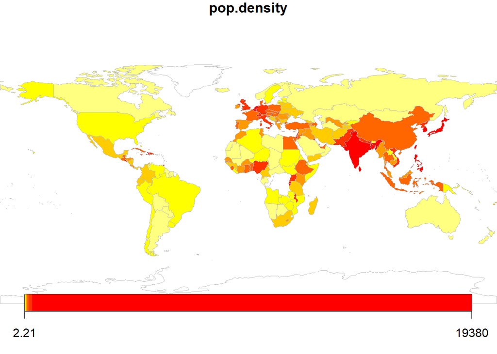

```r
par(mai=c(0,0,0.2,0),xaxs="i",yaxs="i")
mapCountryData(map, nameColumnToPlot="pop.density")
```

### Calculating the average distance between every 2 people on the planet

Next, I use the simulation to estimate the average geodesic distance, and see how does it compares to the average geodesic distance between two random points on earth.

```r
names.wiki <- c("United States", "Kingdom of Denmark", "Republic of the Congo", "Sahrawi Arab Democratic Republic", "United Kingdom", "Somaliland", "Eswatini", "The Bahamas", "The Gambia", "Abkhazia", "United States Minor Outlying Islands", "State of Palestine", "Transnistria", "South Ossetia",  "Northern Cyprus",  "Artsakh", "East Timor", "Trinidad and Tobago")

names.map <- c("USA", "Denmark", "Republic of Congo", "Western Sahara", "UK", "Somalia", "Swaziland", "Bahamas", "Gambia", "Georgia", "USA", "Palestine", "Moldova", "Georgia", "Cyprus",  "Armenia", "Timor-Leste", "Trinidad")
```

One of the parameters of the function I will create is the probability to sample a person from each country, according to population size. I will first calculate this vector of probabilities by calculating the size of the population of the country, divided by the population of the world, which I kept earlier before removing.

```r
# countries <- wikipedia %>% filter(total_in_km2 > 1000) # Ignore countries smaller than 1000 km^2
# wikipedia %>% filter(total_in_km2 > 1000)
countries <- wikipedia
countries$population_ratio <- countries$population/sum(countries$population, na.rm = TRUE)
sum(countries$population_ratio, na.rm = TRUE)
```

```
## [1] 1
```

```r
countries <- data.frame(countries = countries$country_dependency,population_ratio = countries$population_ratio) # Extract the countries

for (i in 1:length(names.map)){
    countries$countries[countries$countries==names.wiki[i]]<-names.map[i];
}

countries <- countries %>% group_by(countries) %>% summarize(population_ratio=sum(population_ratio)) %>% drop_na() # leave only unique values

setdiff(countries$countries, unique(map_data("world")$region)) # countries in my list, but not in the maps' package.
```

```
## [1] "Antigua and Barbuda"              "São Tomé and Príncipe"
## [3] "Saint Kitts and Nevis"            "Saint Vincent and the Grenadines"
## [5] "Tuvalu"                           "Vatican City"
```

Next, I will use a function I created that samples 2 countries from a list, and finds a point within each, using the previously implemented *sample_n_from_country* from Q1. Using *replicate* I will run this function n times, and calculate the mean of the results.

*dist_between_2_people* gets a vector of countries, and a matching vector of probabilities. it samples 2 “people” in the world and finds their countries by actually sampling a country, with a probability to sample the country being the population size divided by the worlds population.

This simulates picking a person randomly from the world, and then finding out its country.

```r
proba <- countries$population_ratio
countries<- countries$countries


dist_between_2_people <- function(countries,proba){
  c1 <- sample(countries,1,replace=TRUE,proba)
  c2 <- sample(countries,1,replace=TRUE,proba)
  p_1<- sample_n_from_country(1,c1)
  p_2<- sample_n_from_country(1,c2)
  return(geodesic_dist(p_1,p_2))

}

dists_between_people <- replicate(100,dist_between_2_people(countries,proba=proba))
mean(dists_between_people)
```

```
## [1] 6438.816
```

The mean of the distances between sampled people is smaller than that of countries. This can be explained mainly by the distribution of the people across countries - It is not uniform, and the probability to sample people from some countries is bigger than others, as the probability is a function of the population size. For example, it is much more likely to sample 2 people from the USA than a person from a USA and a person from Israel. This means that many of the distances could be between people of the same country - and the distances will shorten accordingly. in addition, since we are sampeling people, the points at sea are no longer available for sampeling, which narrows down to a smaller part of the world.

# Part 3 - Estimation of countries’ sizes.

I created several helper function, and then used *appk* and *sapply* to run them over the samples:

**match_country** - The function recieves a vector of long and lat of a single uniformly sampled point on earth, and matches the country the location is in. I use this function in the main function with *apply* in order to match each of the n samples to a country.

**freq_of_country** - Returns the estimated size of a single country. It does so by summing the number of time the country appears in the sampled data, and then divides it by the number of sample, times the size of the earth’s surface. I use this function with sapply for each of the countries on the list.

```r
match_country <- function(point){ # The function recieves a vector of long and lat of a single uniformly sampled point on earth. It matches the country.
  return(map.where("world", list(long=point[1], lat = point[2])))
}

freq_of_country<- function(country, samples_locations, foe){ # returns the frequency of country, out of the n samples
  return(sum(samples_locations==country, na.rm = TRUE)/length(samples_locations)*foe)
}
```

The main function, that uses the helper functions in order to calculate the size of each country on the list:

```r
size_of_countries <- function(countries,n){
  samples <- replicate(n, sample_uniformly()) # n geographic coordinates
  samples_locations <- apply(samples, MARGIN =2, match_country) # create an array sized n with  the country matching each location
  samples_locations <- str_split_fixed(samples_locations, ":",2)[,1] # Some of the countries returned by the *maps.where* function contain "country:location". So I used *str_split_fixed* in order to remove the smaller location, and only leave the country.

  r <- 6371
  foe <- 4*pi*r^2 # Face of earth
  estimated_size <- sapply(countries, freq_of_country, samples_locations = samples_locations, foe = foe)
  estimated_size <- as.data.frame(estimated_size)
  return(estimated_size)
}
```

I will now use the main function in order to calculate the size of the list of countries extracted from Wikipedia:

```r
sample_uniformly<- function(){
  return(spherical_to_geographical(cartesian_to_spherical(sample_point())))
}

countries_size <- wikipedia$country_dependency
for (i in 1:length(names.map)){
    countries_size[countries_size==names.wiki[i]]<-names.map[i];
}

countries_size<-unique(countries_size) # leave only unique values

countries_by_size <- size_of_countries(countries_size,10000)
```

#### Top 10 large countries according to my analysis:

```r
countries_by_size <- countries_by_size %>% arrange(desc(estimated_size))
head(countries_by_size,10)
```

```
##              estimated_size
## Russia             17750244
## China              10303302
## USA                 9130154
## Canada              9028141
## Brazil              8620090
## Australia           7446941
## India               4182529
## Kazakhstan          3162400
## Saudi Arabia        2856361
## Mexico              2550322
```

The two lists have a very high match, both in the top 10 countries, and the sizes are also similar, althogh not accurate.

# Part 4 - Analysis and visualization of earthquake geographical data

```r
df <- read.csv("C:\\Users\\Maya\\Desktop\\School\\Github\\R project\\earthquakes.csv")
```

Five latest earthquakes:

```r
df %>% arrange(desc(time)) %>% head(5)
```

```
##                       time latitude longitude  depth  mag magType nst gap
## 1 2022-06-29T17:50:18.991Z 65.65310 -165.2286   1.50 3.10      ml  NA  NA
## 2 2022-06-29T15:37:39.100Z 34.33933 -119.2072  11.02 2.70      ml  41 100
## 3 2022-06-29T14:13:01.960Z 69.28270 -144.2008  33.00 2.80      ml  NA  NA
## 4 2022-06-29T14:08:04.200Z 40.36650 -125.5813   9.62 3.54      ml  81 255
## 5 2022-06-29T10:55:26.702Z 28.49010  139.4953 444.67 4.10      mb  NA 145
##      dmin  rms net           id                  updated
## 1      NA 0.60  ak ak02289z5lfv 2022-06-29T17:54:16.772Z
## 2 0.03997 0.34  ci   ci40293664 2022-06-29T17:17:08.698Z
## 3      NA 0.96  ak ak02289x5btg 2022-06-29T14:16:59.862Z
## 4 0.95580 0.27  nc   nc73752561 2022-06-29T16:56:14.239Z
## 5 4.61800 0.50  us   us7000hl2a 2022-06-29T11:09:56.040Z
##                           place       type horizontalError depthError magError
## 1    68 km NE of Teller, Alaska earthquake              NA       0.30       NA
## 2        7km NNE of Ventura, CA earthquake            0.55       1.03    0.165
## 3 97 km SSW of Kaktovik, Alaska earthquake              NA       0.50       NA
## 4       110km W of Petrolia, CA earthquake            2.06      31.61    0.233
## 5   Bonin Islands, Japan region earthquake            6.80      10.50    0.099
##   magNst    status locationSource magSource
## 1     NA automatic             ak        ak
## 2     25 automatic             ci        ci
## 3     NA automatic             ak        ak
## 4     48  reviewed             nc        nc
## 5     28  reviewed             us        us
```

Five strongest earthquakes:

```r
df %>% arrange(desc(mag)) %>% head(5)
```

```
##                       time latitude longitude depth mag magType nst gap  dmin
## 1 2022-03-16T14:36:30.997Z  37.7132  141.5793    41 7.3     mww  NA  29 2.936
## 2 2022-05-26T12:02:23.750Z -14.8942  -70.1969   252 7.2     mww  NA  24 2.132
## 3 2022-03-31T05:44:01.146Z -22.5860  170.3744    10 7.0     mww  NA  26 2.705
## 4 2022-05-19T10:13:31.625Z -54.1320  159.0545    10 6.9     mww  NA  45 0.371
## 5 2022-03-30T20:56:58.105Z -22.6660  170.3659    10 6.9     mww  NA  42 2.697
##    rms net         id                  updated
## 1 0.88  us us6000h519 2022-05-27T14:55:19.040Z
## 2 1.23  us us7000hcmn 2022-06-23T07:24:06.051Z
## 3 0.82  us us7000gymk 2022-06-04T20:42:27.040Z
## 4 0.97  us us6000hm9j 2022-06-16T11:17:55.796Z
## 5 1.07  us us7000gyj0 2022-06-04T20:42:25.040Z
##                                 place       type horizontalError depthError
## 1           57 km ENE of Namie, Japan earthquake             6.9        1.9
## 2           1 km N of Az\303¡ngaro, Peru earthquake             8.9        1.9
## 3    southeast of the Loyalty Islands earthquake             7.1        1.8
## 4             Macquarie Island region earthquake             7.3        1.7
## 5 284 km ESE of Tadine, New Caledonia earthquake             8.0        1.8
##   magError magNst   status locationSource magSource
## 1    0.054     33 reviewed             us        us
## 2    0.042     55 reviewed             us        us
## 3    0.057     30 reviewed             us        us
## 4    0.078     16 reviewed             us        us
## 5    0.066     22 reviewed             us        us
```

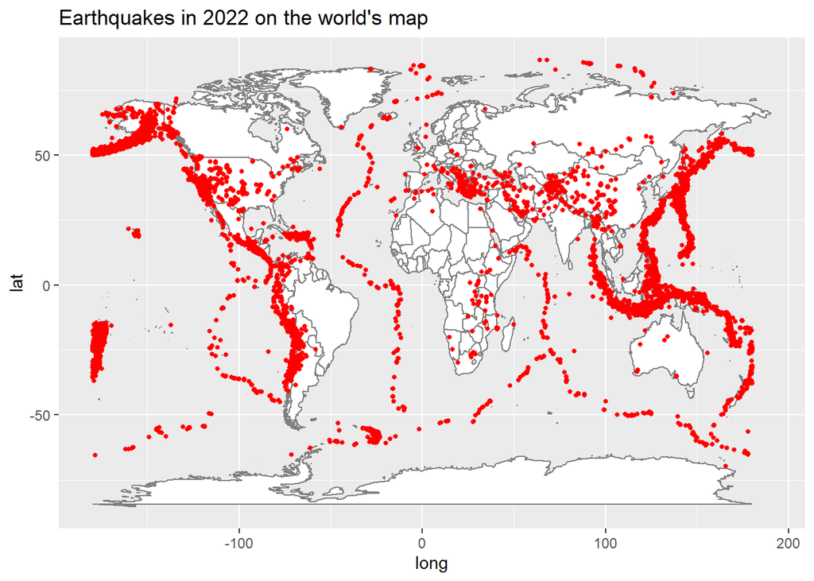

```r
mapWorld <- borders("world", colour="gray50", fill="white") # create a layer of borders

ggplot(df, aes()) + mapWorld + geom_point(aes(x=longitude, y=latitude) ,color="red", size=1) + ggtitle("Earthquakes in 2022 on the world's map")
```

[figure not shown]

```r
ggplot(df%>%filter(mag>2&mag<i+3), aes()) + mapWorld + geom_point(aes(x=longitude, y=latitude) ,color="red", size=1) + ggtitle("Earthquakes 2-3")
```

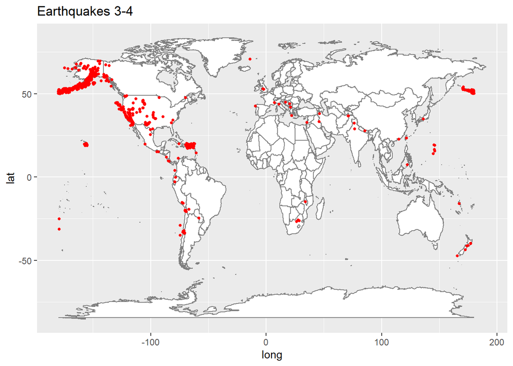

```r
ggplot(df%>%filter(mag>3&mag<4), aes()) + mapWorld + geom_point(aes(x=longitude, y=latitude) ,color="red", size=1) + ggtitle("Earthquakes 3-4")
```

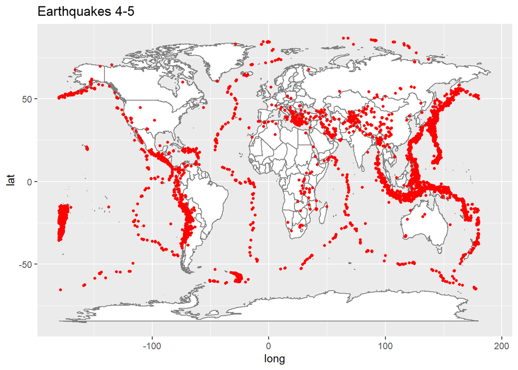

```r
ggplot(df%>%filter(mag>4&mag<5), aes()) + mapWorld + geom_point(aes(x=longitude, y=latitude) ,color="red", size=1) + ggtitle("Earthquakes 4-5")
```

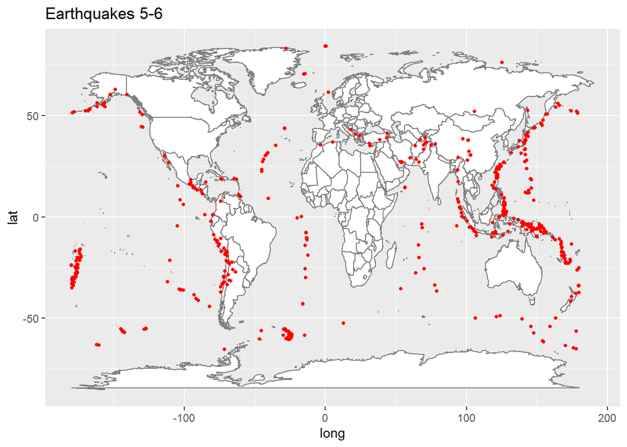

```r
ggplot(df%>%filter(mag>5&mag<6), aes()) + mapWorld + geom_point(aes(x=longitude, y=latitude) ,color="red", size=1) + ggtitle("Earthquakes 5-6")
```

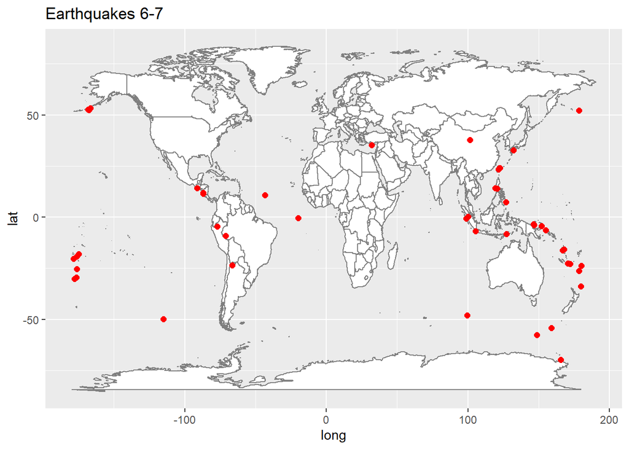

```r
ggplot(df%>%filter(mag>6&mag<7), aes()) + mapWorld + geom_point(aes(x=longitude, y=latitude) ,color="red", size=2) + ggtitle("Earthquakes 6-7")
```

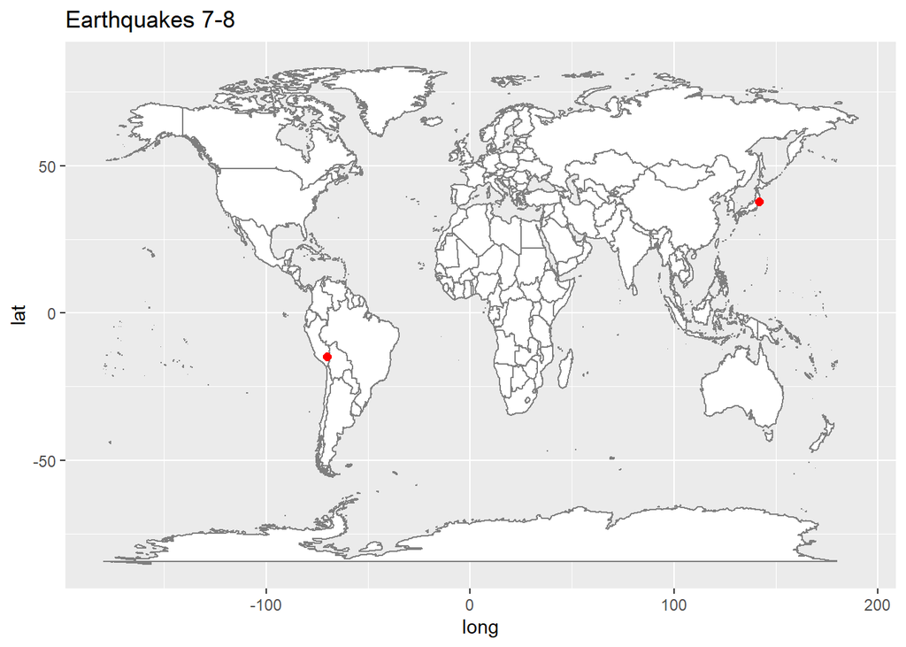

```r
ggplot(df%>%filter(mag>7&mag<8), aes()) + mapWorld + geom_point(aes(x=longitude, y=latitude) ,color="red", size=2) + ggtitle("Earthquakes 7-8")
```

using *Sapply* and a custom function *calc_days* which calcolates the days from the beggining of the year, I created a new column called “day-of-year”. Next, I used *as.POSIXct* to extract the Hours, minutes and seconds, and put them together into hours since midnight.

```r
calc_days <-function(e_date){length(seq(from = as.Date("2022-01-01"),to = e_date,by = 'day'))}


df$date <- as.Date(df$time)
df$day_of_year <- sapply(df$date,calc_days)
df$time_of_day <- round(as.numeric(format(as.POSIXct(as_datetime(df$time)), format = "%H"))+as.numeric(format(as.POSIXct(as_datetime(df$time)), format = "%M"))/60 + as.numeric(format(as.POSIXct(as_datetime(df$time)), format = "%S"))/3600,3)
```

Now for the plot, using ggpairs:

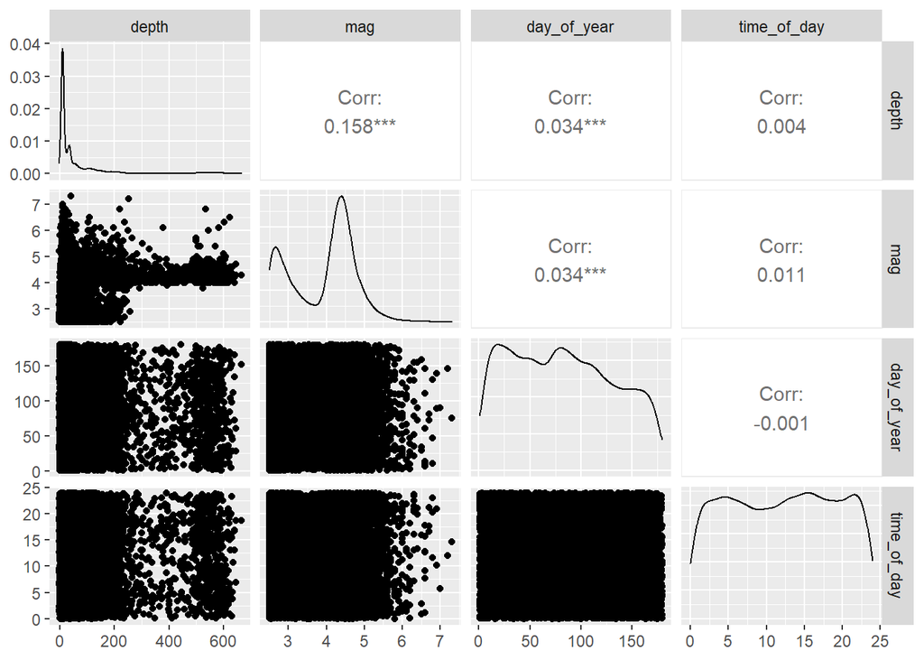

```r
ggpairs(df,columns = c(4,5,24,25))
```

Here I calculate the test statistic s:

```r
e_i <- length(df$time)/24
s=0
for (i in 1:24){
  s_i <- (sum(df$time_of_day>=i-1 & df$time_of_day<i)-e_i)^2/e_i
  s = s + s_i
}

round(s,3)
```

```
## [1] 47.265
```

P-val:

```r
p_val <- 1-pchisq(s,23)
round(p_val,3)
```

```
## [1] 0.002
```

Because the p-value is smaller than alpha of 0.01, we will reject the hypothesis that the distribution of earthquakes over the time of the day is uniform.